# Final Project: Appendices

Jack Boydell

12/3/2019

### 5.0a Appendix: NBA Statistics and Salaries

```r
library(tidyverse)
library(tidyr)
library(leaps)
library(tree)
library(randomForest)
library(GGally)
```

Packages required to run R code and analysis.

```r
salary<-read.csv("NBA_season1718_salary (1).csv", header=TRUE,
                 stringsAsFactors = FALSE)
head(salary)
```

```
##   X         Player  Tm season17_18
## 1 1  Stephen Curry GSW    34682550
## 2 2   LeBron James CLE    33285709
## 3 3   Paul Millsap DEN    31269231
## 4 4 Gordon Hayward BOS    29727900
## 5 5  Blake Griffin DET    29512900
## 6 6     Kyle Lowry TOR    28703704
```

```r
player_stats<-read.csv("nba_extra2.csv", header=TRUE,
                       stringsAsFactors = FALSE)
head(player_stats)
```

```
##   Rk                 Player Pos Age  Tm  G GS   MP  FG FGA   FG. X3P X3PA
## 1 NA                             NA     NA NA   NA  NA  NA    NA  NA   NA
## 2  1 Alex Abrines:abrinal01  SG  24 OKC 75  8 1134 115 291 0.395  84  221
## 3 NA                             NA     NA NA   NA  NA  NA    NA  NA   NA
## 4  2     Quincy Acy:acyqu01  PF  27 BRK 70  8 1359 130 365 0.356 102  292
## 5 NA                             NA     NA NA   NA  NA  NA    NA  NA   NA
## 6  3 Steven Adams:adamsst01   C  24 OKC 76 76 2487 448 712 0.629   0    2
##    X3P. X2P X2PA  X2P.  eFG.  FT FTA   FT. ORB DRB TRB AST STL BLK TOV  PF
## 1    NA  NA   NA    NA    NA  NA  NA    NA  NA  NA  NA  NA  NA  NA  NA  NA
## 2 0.380  31   70 0.443 0.540  39  46 0.848  26  88 114  28  38   8  25 124
## 3    NA  NA   NA    NA    NA  NA  NA    NA  NA  NA  NA  NA  NA  NA  NA  NA
## 4 0.349  28   73 0.384 0.496  49  60 0.817  40 217 257  57  33  29  60 149
## 5    NA  NA   NA    NA    NA  NA  NA    NA  NA  NA  NA  NA  NA  NA  NA  NA
## 6 0.000 448  710 0.631 0.629 160 286 0.559 384 301 685  88  92  78 128 215
##    PTS
## 1   NA
## 2  353
## 3   NA
## 4  411
## 5   NA
## 6 1056
```

```r
summary(player_stats)
```

```
##        Rk           Player              Pos                 Age
##  Min.   :  1.0   Length:1328        Length:1328        Min.   :19.00
##  1st Qu.:139.0   Class :character   Class :character   1st Qu.:23.00
##  Median :266.5   Mode  :character   Mode  :character   Median :26.00
##  Mean   :270.8                                         Mean   :26.19
##  3rd Qu.:401.2                                         3rd Qu.:29.00
##  Max.   :540.0                                         Max.   :41.00
##  NA's   :664                                           NA's   :664
##       Tm                  G               GS              MP
##  Length:1328        Min.   : 1.00   Min.   : 0.00   Min.   :   1.0
##  Class :character   1st Qu.:17.00   1st Qu.: 0.00   1st Qu.: 186.0
##  Mode  :character   Median :46.00   Median : 4.00   Median : 755.0
##                     Mean   :43.28   Mean   :19.71   Mean   : 972.9
##                     3rd Qu.:71.00   3rd Qu.:35.00   3rd Qu.:1651.5
##                     Max.   :82.00   Max.   :82.00   Max.   :3026.0
##                     NA's   :664     NA's   :664     NA's   :664
##        FG             FGA              FG.              X3P
##  Min.   :  0.0   Min.   :   0.0   Min.   :0.0000   Min.   :  0.00
##  1st Qu.: 22.0   1st Qu.:  58.0   1st Qu.:0.3950   1st Qu.:  1.75
##  Median :102.0   Median : 224.5   Median :0.4400   Median : 18.00
##  Mean   :159.5   Mean   : 347.2   Mean   :0.4414   Mean   : 42.27
##  3rd Qu.:253.0   3rd Qu.: 554.0   3rd Qu.:0.4930   3rd Qu.: 64.25
##  Max.   :857.0   Max.   :1687.0   Max.   :1.0000   Max.   :265.00
##  NA's   :664     NA's   :664      NA's   :668      NA's   :664
##       X3PA            X3P.             X2P             X2PA
##  Min.   :  0.0   Min.   :0.0000   Min.   :  0.0   Min.   :   0.0
##  1st Qu.:  7.0   1st Qu.:0.2500   1st Qu.: 15.0   1st Qu.:  33.0
##  Median : 56.5   Median :0.3370   Median : 71.0   Median : 143.0
##  Mean   :117.2   Mean   :0.3100   Mean   :117.2   Mean   : 230.0
##  3rd Qu.:189.2   3rd Qu.:0.3795   3rd Qu.:181.2   3rd Qu.: 361.2
##  Max.   :722.0   Max.   :1.0000   Max.   :725.0   Max.   :1361.0
##  NA's   :664     NA's   :729      NA's   :664     NA's   :664
##       X2P.             eFG.             FT              FTA
##  Min.   :0.0000   Min.   :0.000   Min.   :  0.00   Min.   :  0.00
##  1st Qu.:0.4422   1st Qu.:0.458   1st Qu.:  8.00   1st Qu.: 12.00
##  Median :0.4980   Median :0.506   Median : 37.50   Median : 51.00
##  Mean   :0.4931   Mean   :0.498   Mean   : 66.93   Mean   : 87.19
##  3rd Qu.:0.5468   3rd Qu.:0.551   3rd Qu.: 97.00   3rd Qu.:120.75
##  Max.   :1.0000   Max.   :1.500   Max.   :624.00   Max.   :727.00
##  NA's   :682      NA's   :668     NA's   :664      NA's   :664
```

[output cut: 9 more lines]

```
##  Min.   :  0.00   Min.   :  0.00   Min.   :  0.00   Min.   :  0.00
##  1st Qu.: 11.75   1st Qu.:  5.00   1st Qu.:  2.00   1st Qu.:  8.00
##  Median : 51.00   Median : 23.00   Median : 10.00   Median : 36.00
##  Mean   : 93.18   Mean   : 31.15   Mean   : 19.01   Mean   : 55.01
##  3rd Qu.:126.25   3rd Qu.: 47.00   3rd Qu.: 25.00   3rd Qu.: 86.00
##  Max.   :820.00   Max.   :177.00   Max.   :193.00   Max.   :381.00
##  NA's   :664      NA's   :664      NA's   :664      NA's   :664
##        PF              PTS
##  Min.   :  0.00   Min.   :   0.0
##  1st Qu.: 16.75   1st Qu.:  59.0
##  Median : 66.50   Median : 264.0
##  Mean   : 79.91   Mean   : 428.1
##  3rd Qu.:132.00   3rd Qu.: 667.2
##  Max.   :285.00   Max.   :2251.0
##  NA's   :664      NA's   :664
```

Loading and labeling of the two datasets that will be manipulated and joined to create the final dataset that will be used in the NBA Statistics and Salaries analysis.

```r
player_stats2<-player_stats%>%
  filter(is.na(Rk)==FALSE)

head(player_stats2)
```

```
##   Rk                  Player Pos Age  Tm  G GS   MP  FG FGA   FG. X3P X3PA
## 1  1  Alex Abrines:abrinal01  SG  24 OKC 75  8 1134 115 291 0.395  84  221
## 2  2      Quincy Acy:acyqu01  PF  27 BRK 70  8 1359 130 365 0.356 102  292
## 3  3  Steven Adams:adamsst01   C  24 OKC 76 76 2487 448 712 0.629   0    2
## 4  4   Bam Adebayo:adebaba01   C  20 MIA 69 19 1368 174 340 0.512   0    7
## 5  5 Arron Afflalo:afflaar01  SG  32 ORL 53  3  682  65 162 0.401  27   70
## 6  6  Cole Aldrich:aldrico01   C  29 MIN 21  0   49   5  15 0.333   0    0
##    X3P. X2P X2PA  X2P.  eFG.  FT FTA   FT. ORB DRB TRB AST STL BLK TOV  PF
## 1 0.380  31   70 0.443 0.540  39  46 0.848  26  88 114  28  38   8  25 124
## 2 0.349  28   73 0.384 0.496  49  60 0.817  40 217 257  57  33  29  60 149
## 3 0.000 448  710 0.631 0.629 160 286 0.559 384 301 685  88  92  78 128 215
## 4 0.000 174  333 0.523 0.512 129 179 0.721 118 263 381 101  32  41  66 138
## 5 0.386  38   92 0.413 0.485  22  26 0.846   4  62  66  30   4   9  21  56
## 6    NA   5   15 0.333 0.333   2   6 0.333   3  12  15   3   2   1   1  11
##    PTS
## 1  353
## 2  411
## 3 1056
## 4  477
## 5  179
## 6   12
```

```r
player_stats3 <- player_stats2[-c(24, 25, 28, 29, 45, 46, 59, 60, 68, 69, 70, 73, 74, 77, 78, 97, 98, 102, 103, 118, 119, 122, 123, 142, 143, 145, 146, 167, 168, 174, 175, 180, 181, 190, 191, 202, 203, 229, 230, 237, 238, 242, 243, 250, 251, 252, 259, 260, 266, 267, 276, 277, 288, 289, 299, 300, 306, 307, 314, 315, 319, 320, 328, 329, 331, 332, 342, 342, 343, 344, 368, 369, 386, 387, 401, 402, 419, 420, 425, 426, 427, 439, 440, 442, 443, 450, 451, 454, 455, 471, 472, 481, 482, 493, 494, 496, 497, 523, 524, 535, 536, 550, 551, 568, 569, 585, 586, 602, 603, 604, 606, 607, 610, 611, 623, 624, 642, 643, 650, 651, 660, 661),]
head (player_stats3)
```

```
##   Rk                  Player Pos Age  Tm  G GS   MP  FG FGA   FG. X3P X3PA
## 1  1  Alex Abrines:abrinal01  SG  24 OKC 75  8 1134 115 291 0.395  84  221
## 2  2      Quincy Acy:acyqu01  PF  27 BRK 70  8 1359 130 365 0.356 102  292
## 3  3  Steven Adams:adamsst01   C  24 OKC 76 76 2487 448 712 0.629   0    2
## 4  4   Bam Adebayo:adebaba01   C  20 MIA 69 19 1368 174 340 0.512   0    7
## 5  5 Arron Afflalo:afflaar01  SG  32 ORL 53  3  682  65 162 0.401  27   70
## 6  6  Cole Aldrich:aldrico01   C  29 MIN 21  0   49   5  15 0.333   0    0
##    X3P. X2P X2PA  X2P.  eFG.  FT FTA   FT. ORB DRB TRB AST STL BLK TOV  PF
## 1 0.380  31   70 0.443 0.540  39  46 0.848  26  88 114  28  38   8  25 124
## 2 0.349  28   73 0.384 0.496  49  60 0.817  40 217 257  57  33  29  60 149
## 3 0.000 448  710 0.631 0.629 160 286 0.559 384 301 685  88  92  78 128 215
## 4 0.000 174  333 0.523 0.512 129 179 0.721 118 263 381 101  32  41  66 138
## 5 0.386  38   92 0.413 0.485  22  26 0.846   4  62  66  30   4   9  21  56
## 6    NA   5   15 0.333 0.333   2   6 0.333   3  12  15   3   2   1   1  11
##    PTS
## 1  353
## 2  411
## 3 1056
## 4  477
## 5  179
## 6   12
```

Due to the format of the Kaggle data set “nba_extra2” accounting for certain players playing for multiple teams in one year (trades, free-agent signings,etc). Some players for example orginially had three rows or sets of oberservations: one for each team they played for and a total row (the two separate team stats together). These instances were manually identified and removed using this section of code. After this procedure, each NBA player only had one row/set of observations that accounts for his total statistics from that season.

```r
playerS<-separate(data=player_stats3,col=Player,into=c("Player", "nickname"), sep=":")
head(playerS)
```

```
##   Rk        Player  nickname Pos Age  Tm  G GS   MP  FG FGA   FG. X3P X3PA
## 1  1  Alex Abrines abrinal01  SG  24 OKC 75  8 1134 115 291 0.395  84  221
## 2  2    Quincy Acy   acyqu01  PF  27 BRK 70  8 1359 130 365 0.356 102  292
## 3  3  Steven Adams adamsst01   C  24 OKC 76 76 2487 448 712 0.629   0    2
## 4  4   Bam Adebayo adebaba01   C  20 MIA 69 19 1368 174 340 0.512   0    7
## 5  5 Arron Afflalo afflaar01  SG  32 ORL 53  3  682  65 162 0.401  27   70
## 6  6  Cole Aldrich aldrico01   C  29 MIN 21  0   49   5  15 0.333   0    0
##    X3P. X2P X2PA  X2P.  eFG.  FT FTA   FT. ORB DRB TRB AST STL BLK TOV  PF
## 1 0.380  31   70 0.443 0.540  39  46 0.848  26  88 114  28  38   8  25 124
## 2 0.349  28   73 0.384 0.496  49  60 0.817  40 217 257  57  33  29  60 149
## 3 0.000 448  710 0.631 0.629 160 286 0.559 384 301 685  88  92  78 128 215
## 4 0.000 174  333 0.523 0.512 129 179 0.721 118 263 381 101  32  41  66 138
## 5 0.386  38   92 0.413 0.485  22  26 0.846   4  62  66  30   4   9  21  56
## 6    NA   5   15 0.333 0.333   2   6 0.333   3  12  15   3   2   1   1  11
##    PTS
## 1  353
## 2  411
## 3 1056
## 4  477
## 5  179
## 6   12
```

In this section of code the separate function is used to separate the “Player” and “nickname” by ‘:’ so the two datasets can be joined by the similar column of “Player” each player’s full name.

```r
data<-left_join(playerS, salary)
data<-data%>%
  mutate(MPG = MP/G, PPG = PTS/G, APG = AST/G, RPG = TRB/G, TOG = TOV/G, GSR = GS/G)
data<-na.omit(data)
attach(data)
```

This section of code joins “playerS” and “salary” using the left_join function and creates the per game basis metrics using the mutata function. Na.omit works to removed any empty values (NAs) from the dataset.

```r
data.pure <- data
data.pure$Player <- data.pure$nickname <- data.pure$Tm <- data.pure$Pos <- data.pure$Rk <- data.pure$X <- NULL
```

The final dataset titled data is copied and any non-numerical or unimportant variable is removed. This allows for no confusion in later outputs of pairs correlation plots and puts a focus on the statisitics that will be used in analysis.

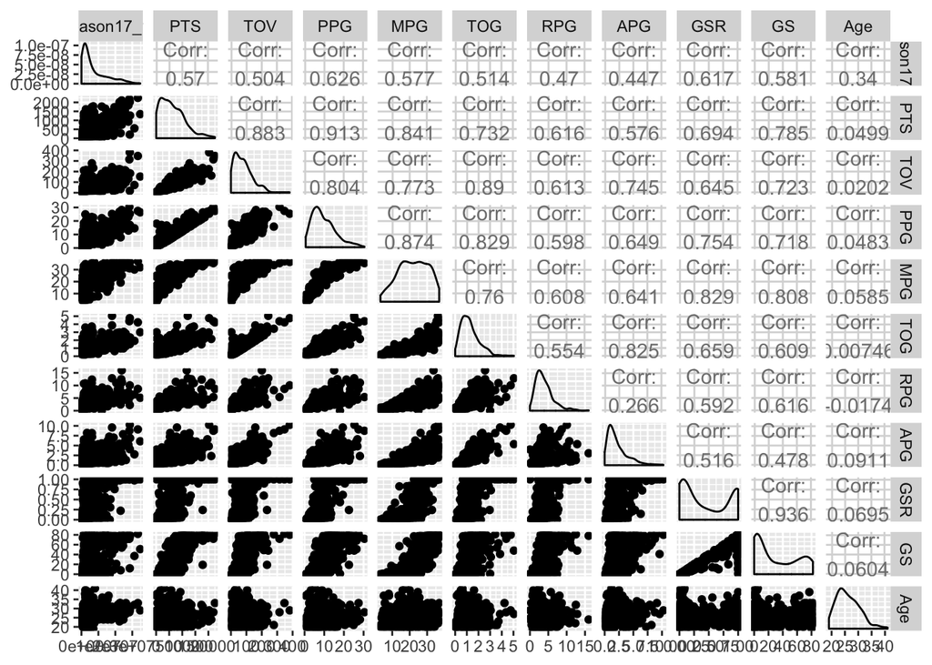

```r
stats_salary_cor <- data %>%
  select(season17_18, PTS, TOV, PPG, MPG, TOG, RPG, APG, GSR, GS, Age)
ggpairs(stats_salary_cor)
```

```r
cor(stats_salary_cor)[,"season17_18"]
```

```
## season17_18         PTS         TOV         PPG         MPG         TOG
##   1.0000000   0.5700031   0.5041297   0.6256246   0.5770201   0.5142743
##         RPG         APG         GSR          GS         Age
##   0.4696220   0.4472140   0.6165369   0.5814952   0.3400804
```

A pairs correlation plot is created to highlight any initial correlation betwen 2017-2018 season salaries adn certain basketball performance statistics.

```r
### importance plot with Random Forest
set.seed(1)
train<-sample(1:nrow(data.pure), nrow(data.pure)/2)
NBA.test <- data.pure[-train, "season17_18"]
rf.NBA<-randomForest(season17_18~., data=data.pure, subset=train,
                     importance=TRUE)
yhat.rf<-predict(rf.NBA, newdata=data.pure[-train,])
mean((yhat.rf-NBA.test)^2)
```

```
## [1] 2.384387e+13
```

```r
importance(rf.NBA)
```

```
##          %IncMSE IncNodePurity
## Age  19.82939349  8.888248e+14
## G    -0.13743537  1.015118e+14
## GS    7.71891629  5.355915e+14
## MP    3.78119908  2.517207e+14
## FG    2.95021921  3.009064e+14
## FGA   2.49550348  1.631564e+14
## FG.   2.17875857  1.444834e+14
## X3P   1.93042097  1.524405e+14
## X3PA  1.58665840  1.760458e+14
## X3P.  0.02162664  1.774951e+14
## X2P   3.41344048  1.198227e+14
## X2PA  2.93144331  9.615173e+13
## X2P.  1.75340769  1.402969e+14
## eFG.  4.04310256  1.959106e+14
## FT    4.52118980  2.628892e+14
## FTA   3.34048057  2.111980e+14
## FT.  -0.73169010  1.012629e+14
## ORB   5.77684594  1.640142e+14
## DRB   3.23270186  2.494882e+14
## TRB   2.44718503  1.543428e+14
## AST   3.28501983  1.513149e+14
## STL   3.57376725  1.290821e+14
## BLK   3.67570702  2.060660e+14
## TOV   1.34628620  1.178515e+14
## PF    2.05348264  9.718817e+13
## PTS   4.72941165  3.838420e+14
## MPG  10.92719034  1.262266e+15
## PPG  12.52826764  1.349134e+15
## APG   2.68593451  3.051066e+14
## RPG   9.12615393  2.679921e+14
## TOG   3.44002007  1.690668e+14
## GSR  20.11974893  2.313002e+15
```

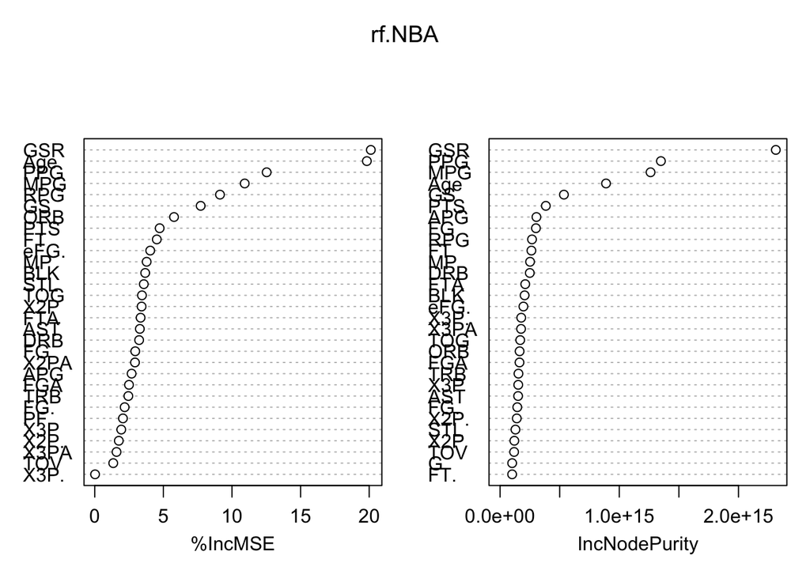

```r
varImpPlot(rf.NBA)
```

Using the randomForest package, a training subset is taken from the data.pure dataset and applied to produce a variable importance plot (discussed in body of the report).

```r
### tree with cross validation for pruning
set.seed(1)
train<-sample(1:nrow(data.pure), nrow(data.pure)/2)
NBA.test <- data.pure[-train, "season17_18"]
tree.NBA<-tree(season17_18~., data.pure, subset=train)
summary(tree.NBA)
```

```
##
## Regression tree:
## tree(formula = season17_18 ~ ., data = data.pure, subset = train)
## Variables actually used in tree construction:
## [1] "GSR"  "Age"  "ORB"  "MP"   "PPG"  "TRB"  "X3P." "STL"
## Number of terminal nodes:  11
## Residual mean deviance:  1.003e+13 = 1.735e+15 / 173
## Distribution of residuals:
##      Min.   1st Qu.    Median      Mean   3rd Qu.      Max.
## -10110000  -1884000   -454700         0   1388000   9705000
```

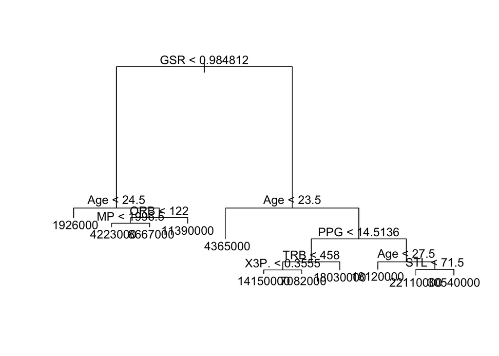

```r
plot(tree.NBA)
text(tree.NBA, pretty = 0)
```

The same train subset is created and applied to the tree algorithim to create the recursive binary spltting diagram (discussed in body of the report).

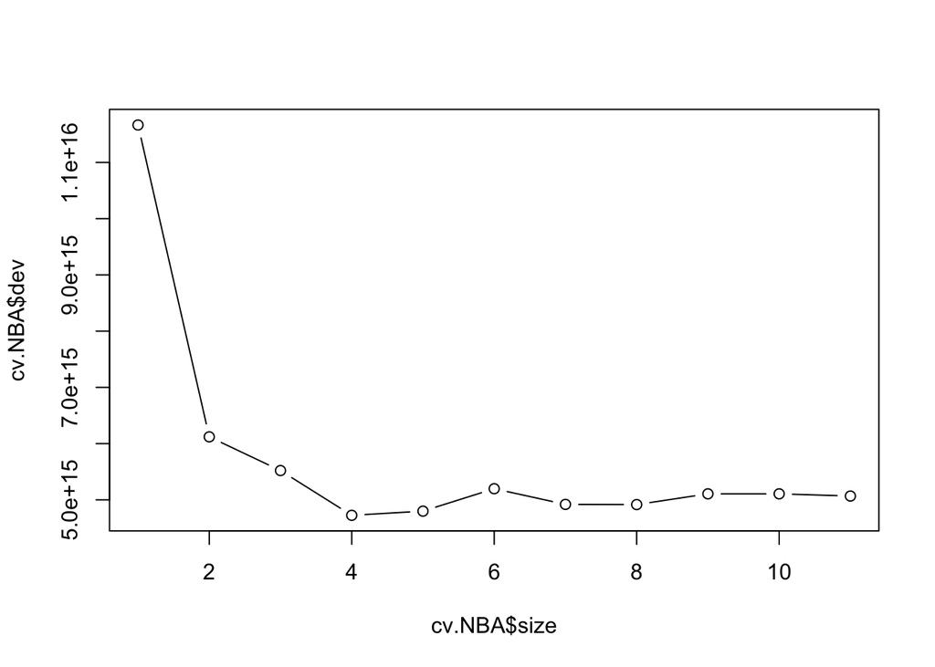

```r
cv.NBA<-cv.tree(tree.NBA)
plot(cv.NBA$size, cv.NBA$dev, type='b')
```

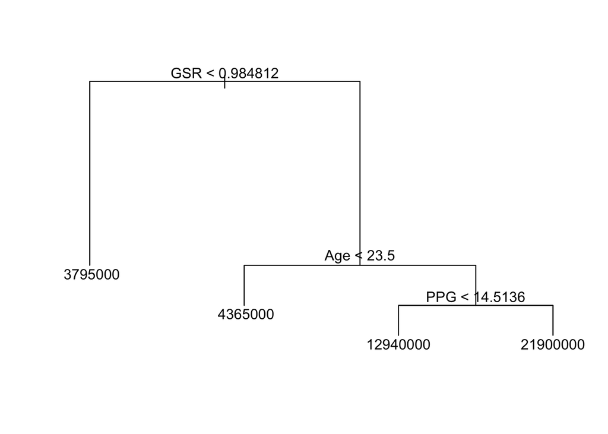

```r
prune.NBA<-prune.tree(tree.NBA, best=4)
plot(prune.NBA)
text(prune.NBA, pretty=0)
```

Cross-validation for the number of terminal nodes(4) is performed and used in coordination with the prune.tree function is modify the tree plot.

```r
mod1a <- lm(season17_18~MPG, data = data.pure)
anova(mod1a)
```

```
## Analysis of Variance Table
##
## Response: season17_18
##            Df     Sum Sq    Mean Sq F value    Pr(>F)
## MPG         1 7.0049e+15 7.0049e+15  182.69 < 2.2e-16 ***
## Residuals 366 1.4034e+16 3.8344e+13
## ---
## Signif. codes:  0 '***' 0.001 '**' 0.01 '*' 0.05 '.' 0.1 ' ' 1
```

```r
# RSS = 1.4034e+16

mod1b <- lm(season17_18~PPG, data = data.pure)
anova(mod1b)
```

```
## Analysis of Variance Table
##
## Response: season17_18
##            Df     Sum Sq    Mean Sq F value    Pr(>F)
## PPG         1 8.2346e+15 8.2346e+15  235.39 < 2.2e-16 ***
## Residuals 366 1.2804e+16 3.4984e+13
## ---
## Signif. codes:  0 '***' 0.001 '**' 0.01 '*' 0.05 '.' 0.1 ' ' 1
```

```r
# RSS = 1.2803e+16

mod1c <- lm(season17_18~Age, data = data.pure)
anova(mod1c)
```

```
## Analysis of Variance Table
##
## Response: season17_18
##            Df     Sum Sq    Mean Sq F value    Pr(>F)
## Age         1 2.4332e+15 2.4332e+15  47.865 2.049e-11 ***
## Residuals 366 1.8605e+16 5.0834e+13
## ---
## Signif. codes:  0 '***' 0.001 '**' 0.01 '*' 0.05 '.' 0.1 ' ' 1
```

```r
# RSS = 1.8605e+16

mod1d <- lm(season17_18~GS, data = data.pure)
anova(mod1d)
```

```
## Analysis of Variance Table
##
## Response: season17_18
##            Df     Sum Sq    Mean Sq F value    Pr(>F)
## GS          1 7.1139e+15 7.1139e+15  186.98 < 2.2e-16 ***
## Residuals 366 1.3925e+16 3.8046e+13
## ---
## Signif. codes:  0 '***' 0.001 '**' 0.01 '*' 0.05 '.' 0.1 ' ' 1
```

```r
# RSS = 1.3925e+16

mod1e <- lm(season17_18~GSR, data = data.pure)
anova(mod1e)
```

```
## Analysis of Variance Table
##
## Response: season17_18
##            Df     Sum Sq    Mean Sq F value    Pr(>F)
## GSR         1 7.9972e+15 7.9972e+15  224.43 < 2.2e-16 ***
## Residuals 366 1.3041e+16 3.5632e+13
## ---
## Signif. codes:  0 '***' 0.001 '**' 0.01 '*' 0.05 '.' 0.1 ' ' 1
```

```r
#RSS = 1.3041e+16

mod1e <- lm(season17_18~TOG, data = data.pure)
anova(mod1e)
```

```
## Analysis of Variance Table
##
## Response: season17_18
##            Df     Sum Sq    Mean Sq F value    Pr(>F)
## TOG         1 5.5643e+15 5.5643e+15  131.61 < 2.2e-16 ***
## Residuals 366 1.5474e+16 4.2280e+13
## ---
## Signif. codes:  0 '***' 0.001 '**' 0.01 '*' 0.05 '.' 0.1 ' ' 1
```

```r
# RSS = 1.5474e+16
```

First step of forward selection: testing each explanatory variable in a simple regression format and comaring residual sum of squares (RSS). PPG determined to be the first variable in the model.

```r
mod2a <- lm(season17_18~PPG + Age, data = data.pure)
anova(mod2a)
```

```
## Analysis of Variance Table
##
## Response: season17_18
##            Df     Sum Sq    Mean Sq F value    Pr(>F)
## PPG         1 8.2346e+15 8.2346e+15 278.828 < 2.2e-16 ***
## Age         1 2.0244e+15 2.0244e+15  68.547 2.367e-15 ***
## Residuals 365 1.0780e+16 2.9533e+13
## ---
## Signif. codes:  0 '***' 0.001 '**' 0.01 '*' 0.05 '.' 0.1 ' ' 1
```

```r
# RSS = 1.078e+16

mod2b <- lm(season17_18~PPG + GSR, data = data.pure)
anova(mod2b)
```

```
## Analysis of Variance Table
##
## Response: season17_18
##            Df     Sum Sq    Mean Sq F value    Pr(>F)
## PPG         1 8.2346e+15 8.2346e+15 255.170 < 2.2e-16 ***
## GSR         1 1.0250e+15 1.0250e+15  31.761 3.491e-08 ***
## Residuals 365 1.1779e+16 3.2271e+13
## ---
## Signif. codes:  0 '***' 0.001 '**' 0.01 '*' 0.05 '.' 0.1 ' ' 1
```

```r
# RSS = 1.1779e+16

mod2c <- lm(season17_18~PPG + MPG, data = data.pure)
anova(mod2c)
```

```
## Analysis of Variance Table
##
## Response: season17_18
##            Df     Sum Sq    Mean Sq F value Pr(>F)
## PPG         1 8.2346e+15 8.2346e+15 236.264 <2e-16 ***
## MPG         1 8.2429e+13 8.2429e+13   2.365  0.125
## Residuals 365 1.2722e+16 3.4854e+13
## ---
## Signif. codes:  0 '***' 0.001 '**' 0.01 '*' 0.05 '.' 0.1 ' ' 1
```

```r
# RSS = 1.2722e+16

mod2d <- lm(season17_18~PPG + GS, data = data.pure)
anova(mod2d)
```

```
## Analysis of Variance Table
##
## Response: season17_18
##            Df     Sum Sq    Mean Sq F value    Pr(>F)
## PPG         1 8.2346e+15 8.2346e+15 249.544 < 2.2e-16 ***
## GS          1 7.5942e+14 7.5942e+14  23.014 2.348e-06 ***
## Residuals 365 1.2045e+16 3.2999e+13
## ---
## Signif. codes:  0 '***' 0.001 '**' 0.01 '*' 0.05 '.' 0.1 ' ' 1
```

```r
# RSS = 1.2045e+16

mod2e <- lm(season17_18~PPG + TOG, data = data.pure)
anova(mod2e)
```

```
## Analysis of Variance Table
##
## Response: season17_18
##            Df     Sum Sq    Mean Sq  F value Pr(>F)
## PPG         1 8.2346e+15 8.2346e+15 234.7687 <2e-16 ***
## TOG         1 1.3884e+12 1.3884e+12   0.0396 0.8424
## Residuals 365 1.2803e+16 3.5076e+13
## ---
## Signif. codes:  0 '***' 0.001 '**' 0.01 '*' 0.05 '.' 0.1 ' ' 1
```

```r
# TOG not significant
```

Second step of forward selection: Age determined to be the second vairable in the model.

```r
mod3a <- lm(season17_18~PPG + Age + GSR, data = data.pure)
anova(mod3a)
```

```
## Analysis of Variance Table
##
## Response: season17_18
##            Df     Sum Sq    Mean Sq F value    Pr(>F)
## PPG         1 8.2346e+15 8.2346e+15 302.999 < 2.2e-16 ***
## Age         1 2.0244e+15 2.0244e+15  74.489 < 2.2e-16 ***
## GSR         1 8.8708e+14 8.8708e+14  32.641 2.308e-08 ***
## Residuals 364 9.8925e+15 2.7177e+13
## ---
## Signif. codes:  0 '***' 0.001 '**' 0.01 '*' 0.05 '.' 0.1 ' ' 1
```

```r
#RSS = 9.8925e+15

mod3b <- lm(season17_18~PPG + Age + MPG, data = data.pure)
anova(mod3b)
```

```
## Analysis of Variance Table
##
## Response: season17_18
##            Df     Sum Sq    Mean Sq  F value    Pr(>F)
## PPG         1 8.2346e+15 8.2346e+15 279.5529 < 2.2e-16 ***
## Age         1 2.0244e+15 2.0244e+15  68.7252  2.21e-15 ***
## MPG         1 5.7407e+13 5.7407e+13   1.9489    0.1636
## Residuals 364 1.0722e+16 2.9456e+13
## ---
## Signif. codes:  0 '***' 0.001 '**' 0.01 '*' 0.05 '.' 0.1 ' ' 1
```

```r
# MPG not significant

mod3c <- lm(season17_18~PPG + Age + GS, data = data.pure)
anova(mod3c)
```

```
## Analysis of Variance Table
##
## Response: season17_18
##            Df     Sum Sq    Mean Sq F value    Pr(>F)
## PPG         1 8.2346e+15 8.2346e+15 296.532 < 2.2e-16 ***
## Age         1 2.0244e+15 2.0244e+15  72.899 3.760e-16 ***
## GS          1 6.7135e+14 6.7135e+14  24.175 1.333e-06 ***
## Residuals 364 1.0108e+16 2.7770e+13
## ---
## Signif. codes:  0 '***' 0.001 '**' 0.01 '*' 0.05 '.' 0.1 ' ' 1
```

```r
# RSS = 1.0108e+16

mod3d <- lm(season17_18~PPG + Age + TOG, data = data.pure)
anova(mod3d)
```

```
## Analysis of Variance Table
##
## Response: season17_18
##            Df     Sum Sq    Mean Sq  F value    Pr(>F)
## PPG         1 8.2346e+15 8.2346e+15 278.1187 < 2.2e-16 ***
## Age         1 2.0244e+15 2.0244e+15  68.3727 2.569e-15 ***
## TOG         1 2.1150e+12 2.1150e+12   0.0714    0.7894
## Residuals 364 1.0777e+16 2.9608e+13
## ---
## Signif. codes:  0 '***' 0.001 '**' 0.01 '*' 0.05 '.' 0.1 ' ' 1
```

```r
# TOG not significant
```

Third step of forward selection: GSR is determined to be the third variable in the model.

```r
mod4a <- lm(season17_18~PPG + Age + GSR + MPG, data = data.pure)
anova(mod4a)
```

```
## Analysis of Variance Table
##
## Response: season17_18
##            Df     Sum Sq    Mean Sq  F value    Pr(>F)
## PPG         1 8.2346e+15 8.2346e+15 305.1463 < 2.2e-16 ***
## Age         1 2.0244e+15 2.0244e+15  75.0171 < 2.2e-16 ***
## GSR         1 8.8708e+14 8.8708e+14  32.8719 2.073e-08 ***
## MPG         1 9.6612e+13 9.6612e+13   3.5801   0.05927 .
## Residuals 363 9.7959e+15 2.6986e+13
## ---
## Signif. codes:  0 '***' 0.001 '**' 0.01 '*' 0.05 '.' 0.1 ' ' 1
```

```r
# MPG not significant

mod4b <- lm(season17_18~PPG + Age + GSR + GS, data = data.pure)
anova(mod4b)
```

```
## Analysis of Variance Table
##
## Response: season17_18
##            Df     Sum Sq    Mean Sq  F value    Pr(>F)
## PPG         1 8.2346e+15 8.2346e+15 302.1710 < 2.2e-16 ***
## Age         1 2.0244e+15 2.0244e+15  74.2857 < 2.2e-16 ***
## GSR         1 8.8708e+14 8.8708e+14  32.5514 2.412e-08 ***
## GS          1 1.6006e+11 1.6006e+11   0.0059     0.939
## Residuals 363 9.8923e+15 2.7252e+13
## ---
## Signif. codes:  0 '***' 0.001 '**' 0.01 '*' 0.05 '.' 0.1 ' ' 1
```

```r
# GS not significant

mod4c <- lm(season17_18~PPG + Age + GSR + TOG, data = data.pure)
anova(mod4c)
```

```
## Analysis of Variance Table
##
## Response: season17_18
##            Df     Sum Sq    Mean Sq  F value    Pr(>F)
## PPG         1 8.2346e+15 8.2346e+15 302.2270 < 2.2e-16 ***
## Age         1 2.0244e+15 2.0244e+15  74.2994 < 2.2e-16 ***
## GSR         1 8.8708e+14 8.8708e+14  32.5574 2.405e-08 ***
## TOG         1 1.9904e+12 1.9904e+12   0.0731    0.7871
## Residuals 363 9.8905e+15 2.7247e+13
## ---
## Signif. codes:  0 '***' 0.001 '**' 0.01 '*' 0.05 '.' 0.1 ' ' 1
```

```r
# TOG not significant
```

Fourth step of forward selection: No other variables determined to be significant

```r
set.seed(52)
data[sample(nrow(data),1),]
```

```
##      Rk       Player  nickname Pos Age  Tm  G GS   MP  FG FGA   FG. X3P
## 116 114 Allen Crabbe crabbal01  SG  25 BRK 75 68 2197 337 827 0.407 201
##     X3PA  X3P. X2P X2PA  X2P.  eFG.  FT FTA   FT. ORB DRB TRB AST STL BLK
## 116  532 0.378 136  295 0.461 0.529 115 135 0.852  28 296 324 117  47  35
##     TOV  PF PTS  X season17_18      MPG  PPG  APG  RPG  TOG       GSR
## 116  78 168 990 44    19332500 29.29333 13.2 1.56 4.32 1.04 0.9066667
```

```r
final.model <- lm(season17_18~PPG + Age +GSR, data = data.pure)
anova(final.model)
```

```
## Analysis of Variance Table
##
## Response: season17_18
##            Df     Sum Sq    Mean Sq F value    Pr(>F)
## PPG         1 8.2346e+15 8.2346e+15 302.999 < 2.2e-16 ***
## Age         1 2.0244e+15 2.0244e+15  74.489 < 2.2e-16 ***
## GSR         1 8.8708e+14 8.8708e+14  32.641 2.308e-08 ***
## Residuals 364 9.8925e+15 2.7177e+13
## ---
## Signif. codes:  0 '***' 0.001 '**' 0.01 '*' 0.05 '.' 0.1 ' ' 1
```

```r
new.data<- data.frame(PPG = 13.2, Age = 25, GSR = 1)

final.test <- predict(final.model, new.data)
final.test
```

```
##        1
## 11381341
```

### 5.0b Appendix: College/International and NBA Statistics

```r
firstQT<-data%>%
  filter(season17_18<1465920)
dim(firstQT)
```

```
## [1] 66 39
```

```r
set.seed(1)
samp1<-sample(121, 10)
sampFirst<-firstQT[samp1,]

secondQT<-data%>%
  filter(season17_18>=1465920 & season17_18<3028410)
dim(secondQT)
```

```
## [1] 99 39
```

```r
set.seed(2)
samp2<-sample(122, 10)
sampSecond<-secondQT[samp2,]

thirdQT<-data%>%
  filter(season17_18>=3028410 & season17_18<9539057)
dim(thirdQT)
```

```
## [1] 99 39
```

```r
set.seed(3)
samp3<-sample(122, 10)
sampThird<-thirdQT[samp3,]

fourthQT<-data%>%
  filter(season17_18>=9539097 & season17_18<=34682550)
dim(fourthQT)
```

```
## [1] 104  39
```

```r
set.seed(4)
samp4<-sample(122, 10)
sampFourth<-fourthQT[samp4,]
```

This set of code performs a stratified sample based on the five number summary of the overall dataset (all the players’ salaries in the NBA during the 2017-2018 season) to create four stratas based on salary in dollar amounts. The results of each strata were used to separately research and create a dataframe with thses 40 players (10 from each strata). This new dataset will be used for regression analysis.

```r
college.data <- read.csv("Stratified Sample_NBA stats_Sheet1.csv", header = TRUE,
                         stringsAsFactors = FALSE)
head(college.data)
```

```
##              Player Pos Age  Tm  G GS   MP  FG FGA   FG. X3P X3PA  X3P.
## 1 Willy Hernangomez   C  23 TOT 48  1  495  91 164 0.555   5   12 0.417
## 2         Ivan Rabb  PF  20 MEM 36  5  516  86 152 0.566   0    0    NA
## 3       David Nwaba  SG  25 CHI 70 21 1646 202 423 0.478  18   52 0.346
## 4   Tyler Cavanaugh  PF  23 ATL 39  1  518  67 152 0.441  32   89 0.360
## 5        Tyler Ulis  PG  22 PHO 71 43 1658 214 551 0.388  42  146 0.288
## 6    Ersan Ilyasova  PF  30 TOT 69 43 1729 277 613 0.452  91  253 0.360
##   X2P X2PA  X2P.  eFG.  FT FTA   FT. ORB DRB TRB AST STL BLK TOV  PF PTS
## 1  86  152 0.566 0.570  59  90 0.656  61 122 183  33  18  16  35  64 246
## 2  86  152 0.566 0.566  29  36 0.806  53 105 158  32  12  13  35  55 201
## 3 184  371 0.496 0.499 133 203 0.655  89 237 326 104  59  29  77 158 555
## 4  35   63 0.556 0.546  17  21 0.810  45  82 127  27   9   4  14  61 183
## 5 172  405 0.425 0.426  84 101 0.832  24 104 128 311  70   7 127 120 554
## 6 186  360 0.517 0.526 105 135 0.778 118 287 405  90  61  26  72 157 750
```

```r
college<-read.csv("Stat Project_College_International Data_Sheet1.csv", header=TRUE, stringsAsFactors = FALSE)
head(college)
```

```
##              Player              Team cMPG cPPG cFGM cFGA  cFGp cAPG cRPG
## 1 Willy Hernangomez       Real Madrid 12.6 18.8  7.5 11.2 0.667  1.2 11.0
## 2         Ivan Rabb              Cal  32.6 14.0  4.9 10.1 0.484  1.5 10.5
## 3       David Nwaba          Cal Poly 28.0 12.5  4.4  9.5 0.462  3.5  6.3
## 4   Tyler Cavanaugh George Washington 32.2 18.3  5.7 12.7 0.448  2.0  8.4
## 5        Tyler Ulis          Kentucky 36.8 17.3  5.5 12.6 0.434  7.0  3.0
## 6    Ersan Ilyasova      FC Barcelona 29.0 10.7  4.0  8.0 0.500  0.7  7.6
```

Loading and labeling of the two data sets that will be used in the College and NBA statistics analysis.

```r
pro.college <- left_join(college.data, college)
pro.college<-pro.college%>%
  mutate(MPG = MP/G, PPG = PTS/G, APG = AST/G, RPG = TRB/G, TOG = TOV/G)
pro.college <- na.omit(pro.college)
head(pro.college)
```

```
##              Player Pos Age  Tm  G GS   MP  FG FGA   FG. X3P X3PA  X3P.
## 1 Willy Hernangomez   C  23 TOT 48  1  495  91 164 0.555   5   12 0.417
## 3       David Nwaba  SG  25 CHI 70 21 1646 202 423 0.478  18   52 0.346
## 4   Tyler Cavanaugh  PF  23 ATL 39  1  518  67 152 0.441  32   89 0.360
## 5        Tyler Ulis  PG  22 PHO 71 43 1658 214 551 0.388  42  146 0.288
## 6    Ersan Ilyasova  PF  30 TOT 69 43 1729 277 613 0.452  91  253 0.360
## 7       Travis Wear  SF  27 LAL 17  0  228  25  72 0.347  17   47 0.362
##   X2P X2PA  X2P.  eFG.  FT FTA   FT. ORB DRB TRB AST STL BLK TOV  PF PTS
## 1  86  152 0.566 0.570  59  90 0.656  61 122 183  33  18  16  35  64 246
## 3 184  371 0.496 0.499 133 203 0.655  89 237 326 104  59  29  77 158 555
## 4  35   63 0.556 0.546  17  21 0.810  45  82 127  27   9   4  14  61 183
## 5 172  405 0.425 0.426  84 101 0.832  24 104 128 311  70   7 127 120 554
## 6 186  360 0.517 0.526 105 135 0.778 118 287 405  90  61  26  72 157 750
## 7   8   25 0.320 0.465   8   8 1.000   0  38  38   7   4   5   6  30  75
##                Team cMPG cPPG cFGM cFGA  cFGp cAPG cRPG      MPG       PPG
## 1       Real Madrid 12.6 18.8  7.5 11.2 0.667  1.2 11.0 10.31250  5.125000
## 3          Cal Poly 28.0 12.5  4.4  9.5 0.462  3.5  6.3 23.51429  7.928571
## 4 George Washington 32.2 18.3  5.7 12.7 0.448  2.0  8.4 13.28205  4.692308
## 5          Kentucky 36.8 17.3  5.5 12.6 0.434  7.0  3.0 23.35211  7.802817
## 6      FC Barcelona 29.0 10.7  4.0  8.0 0.500  0.7  7.6 25.05797 10.869565
## 7              UCLA 23.9  7.2  3.1  5.8 0.530  1.4  3.2 13.41176  4.411765
##         APG      RPG       TOG
## 1 0.6875000 3.812500 0.7291667
## 3 1.4857143 4.657143 1.1000000
## 4 0.6923077 3.256410 0.3589744
## 5 4.3802817 1.802817 1.7887324
## 6 1.3043478 5.869565 1.0434783
## 7 0.4117647 2.235294 0.3529412
```

This section of code joins “college.data” and “college” by the Player column using the left_join function and creates the per game basis metrics using the mutata function. Na.omit works to removed any empty values (NAs) from the dataset.

```r
pro.college <- na.omit(pro.college)
pro.college.pure <- pro.college
pro.college.pure$Player <- pro.college.pure$Tm <- pro.college.pure$Team <- pro.college.pure$Pos <- NULL
```

The final dataset titled data is copied and any non-numerical or unimportant variable is removed. This allows for no confusion in later outputs of pairs correlation plots and puts a focus on the statisitics that will be used in analysis.

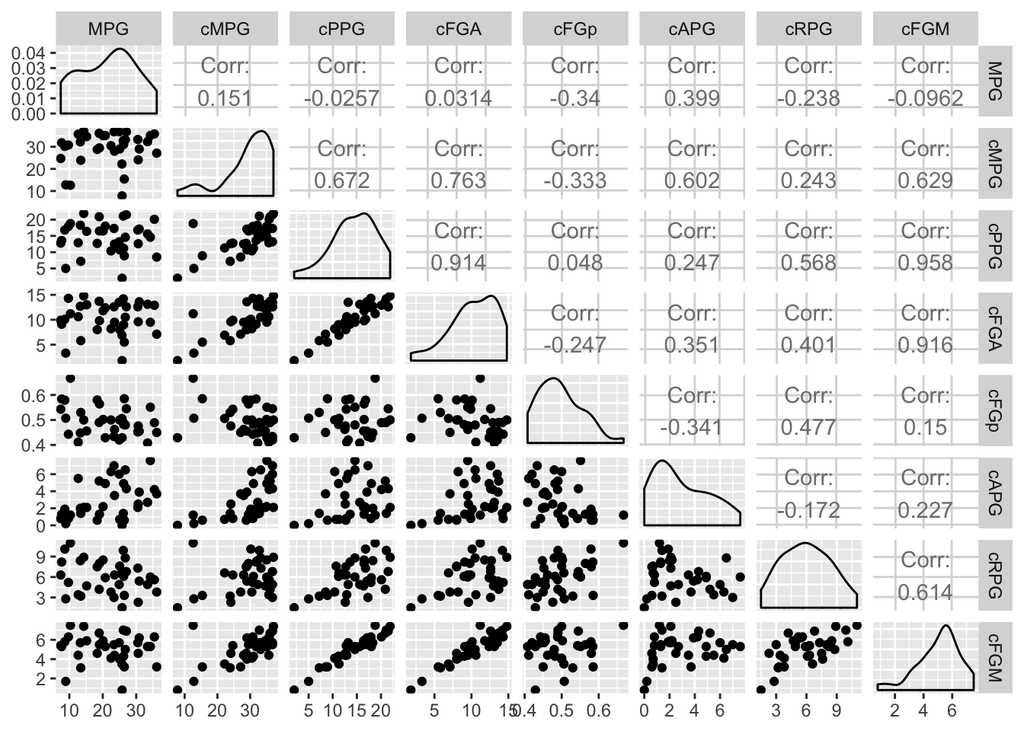

```r
stats_college_cor <- pro.college %>%
  select(MPG, cMPG, cPPG, cFGA, cFGp, cAPG, cRPG, cFGM)
ggpairs(stats_college_cor)
```

```r
cor(stats_college_cor)[,"MPG"]
```

```
##         MPG        cMPG        cPPG        cFGA        cFGp        cAPG
##  1.00000000  0.15077490 -0.02568161  0.03141627 -0.34032515  0.39943917
##        cRPG        cFGM
## -0.23779916 -0.09621396
```

A pairs correlation plot is created to highlight any initial correlation betwen MGP in the 2017-2018 NBA season and certain basketball performance statistics from the college or international season prior to entering the league.

```r
set.seed(2)
train<-sample(1:nrow(pro.college.pure), nrow(pro.college.pure)/2)
set.seed(2)
rf.College<-randomForest(MPG~cMPG+cRPG+cPPG+cAPG+cFGM+cFGA+cFGp, data=pro.college.pure, subset=train,
                     importance=TRUE)
yhat.rf<-predict(rf.College, newdata=pro.college.pure[-train,])
mean((yhat.rf-NBA.test)^2)
```

```
## [1] 9.713284e+13
```

```r
importance(rf.College)
```

```
##         %IncMSE IncNodePurity
## cMPG  0.5627210     193.13778
## cRPG -0.3501000     146.28648
## cPPG  0.4079435     126.09444
## cAPG  5.9093233     296.70085
## cFGM -2.4516593      90.52356
## cFGA -1.5832037     127.53237
## cFGp -1.3091603     197.97435
```

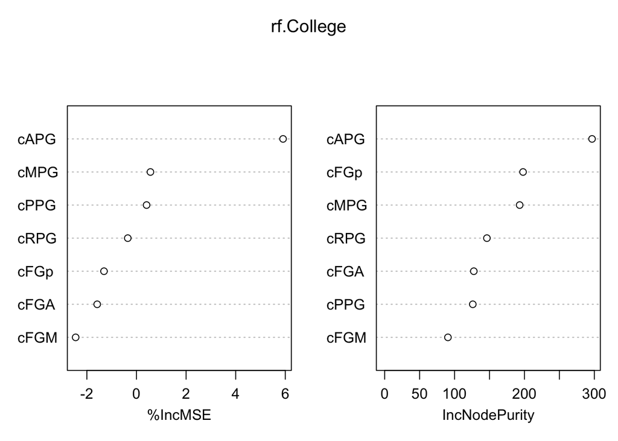

```r
varImpPlot(rf.College)
```

Using the randomForest package, a training subset is taken from the pro.college.pure dataset and applied to produce a variable importance plot (discussed in body of the report).

```r
College.test <- data.pure[-train, "MPG"]
tree.College<-tree(MPG~cMPG+cRPG+cPPG+cAPG+cFGM+cFGA+cFGp, pro.college.pure, subset=train)
summary(tree.College)
```

```
##
## Regression tree:
## tree(formula = MPG ~ cMPG + cRPG + cPPG + cAPG + cFGM + cFGA +
##     cFGp, data = pro.college.pure, subset = train)
## Variables actually used in tree construction:
## [1] "cAPG"
## Number of terminal nodes:  2
## Residual mean deviance:  58.38 = 875.7 / 15
## Distribution of residuals:
##    Min. 1st Qu.  Median    Mean 3rd Qu.    Max.
## -14.380  -5.358  -1.667   0.000   6.364  11.350
```

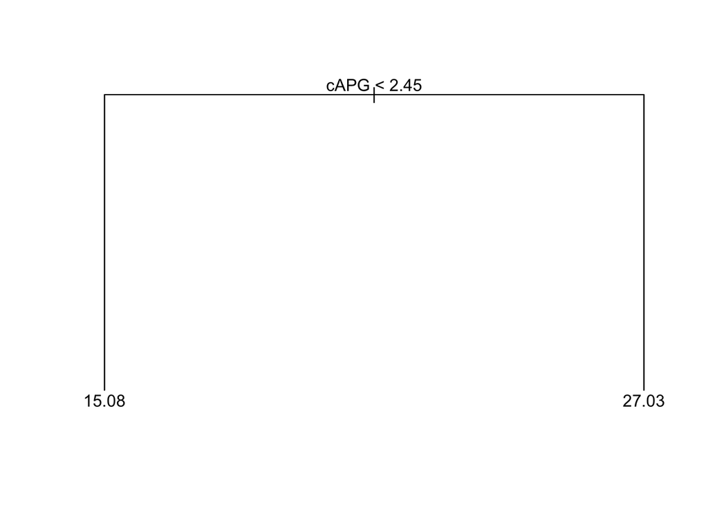

```r
plot(tree.College)
text(tree.College, pretty = 0)
```

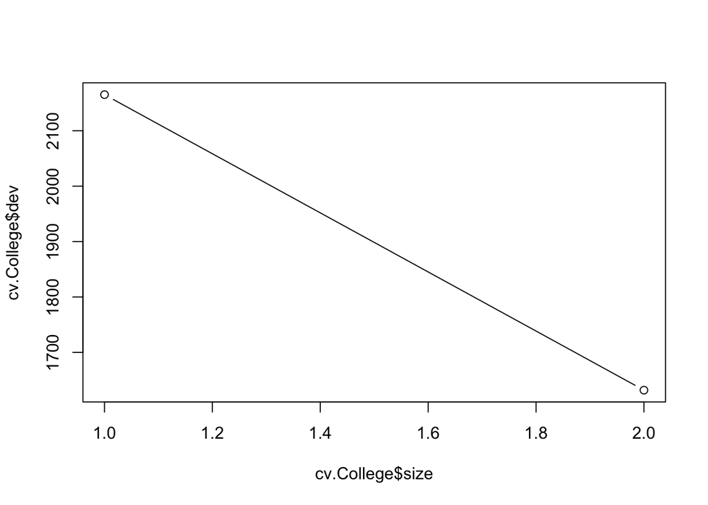

```r
cv.College<-cv.tree(tree.College)
plot(cv.College$size, cv.College$dev, type='b')
```

This code sets a seed for the train subset of the pro.college.pure dataset and uses that subset to apply the tree algorithim and plot. No pruning by cross-validation needed in this instance.

```r
MOD1a <- lm(MPG~cRPG, data = pro.college.pure)
anova(MOD1a)
```

```
## Analysis of Variance Table
##
## Response: MPG
##           Df  Sum Sq Mean Sq F value Pr(>F)
## cRPG       1  139.32 139.322  1.9779  0.169
## Residuals 33 2324.44  70.438
```

```r
# RSS = 2324.44

MOD1b <- lm(MPG~cAPG, data = pro.college.pure)
anova(MOD1b)
```

```
## Analysis of Variance Table
##
## Response: MPG
##           Df Sum Sq Mean Sq F value  Pr(>F)
## cAPG       1  393.1  393.10  6.2648 0.01744 *
## Residuals 33 2070.7   62.75
## ---
## Signif. codes:  0 '***' 0.001 '**' 0.01 '*' 0.05 '.' 0.1 ' ' 1
```

```r
# RSS = 2070.7

MOD1c <- lm(MPG~cFGA, data = pro.college.pure)
anova(MOD1c)
```

```
## Analysis of Variance Table
##
## Response: MPG
##           Df  Sum Sq Mean Sq F value Pr(>F)
## cFGA       1    2.43   2.432  0.0326 0.8578
## Residuals 33 2461.33  74.586
```

```r
# RSS = 2440.96

MOD1d <- lm(MPG~cFGp, data = pro.college.pure)
anova(MOD1d)
```

```
## Analysis of Variance Table
##
## Response: MPG
##           Df  Sum Sq Mean Sq F value  Pr(>F)
## cFGp       1  285.36 285.356  4.3228 0.04545 *
## Residuals 33 2178.41  66.012
## ---
## Signif. codes:  0 '***' 0.001 '**' 0.01 '*' 0.05 '.' 0.1 ' ' 1
```

```r
# RSS = 2178.41

MOD1e <- lm(MPG~cPPG, data = pro.college.pure)
anova(MOD1e)
```

```
## Analysis of Variance Table
##
## Response: MPG
##           Df  Sum Sq Mean Sq F value Pr(>F)
## cPPG       1    1.62   1.625  0.0218 0.8836
## Residuals 33 2462.14  74.610
```

```r
# RSS = 2462.14

MOD1f <- lm(MPG~cMPG, data = pro.college.pure)
anova(MOD1f)
```

```
## Analysis of Variance Table
##
## Response: MPG
##           Df  Sum Sq Mean Sq F value Pr(>F)
## cMPG       1   56.01  56.009  0.7676 0.3873
## Residuals 33 2407.75  72.962
```

```r
# RSS = 2407.75
```

First step of forward selection: testing each explanatory variable in a simple regression format and comaring residual sum of squares (RSS). cAPG determined to be the first variable in the model.

```r
MOD2a <- lm(MPG~cAPG + cFGA, data = pro.college.pure)
anova(MOD2a)
```

```
## Analysis of Variance Table
##
## Response: MPG
##           Df  Sum Sq Mean Sq F value  Pr(>F)
## cAPG       1  393.10  393.10  6.1743 0.01838 *
## cFGA       1   33.33   33.33  0.5236 0.47458
## Residuals 32 2037.33   63.67
## ---
## Signif. codes:  0 '***' 0.001 '**' 0.01 '*' 0.05 '.' 0.1 ' ' 1
```

```r
MOD2b <- lm(MPG~cAPG + cPPG, data = pro.college.pure)
anova(MOD2b)
```

```
## Analysis of Variance Table
##
## Response: MPG
##           Df Sum Sq Mean Sq F value  Pr(>F)
## cAPG       1  393.1  393.10  6.1964 0.01819 *
## cPPG       1   40.6   40.60  0.6400 0.42961
## Residuals 32 2030.1   63.44
## ---
## Signif. codes:  0 '***' 0.001 '**' 0.01 '*' 0.05 '.' 0.1 ' ' 1
```

```r
MOD2c <- lm(MPG~cAPG + cFGM, data = pro.college.pure)
anova(MOD2c)
```

```
## Analysis of Variance Table
##
## Response: MPG
##           Df  Sum Sq Mean Sq F value Pr(>F)
## cAPG       1  393.10  393.10  6.3531 0.0169 *
## cFGM       1   90.66   90.66  1.4652 0.2350
## Residuals 32 1980.00   61.88
## ---
## Signif. codes:  0 '***' 0.001 '**' 0.01 '*' 0.05 '.' 0.1 ' ' 1
```

```r
MOD2d <- lm(MPG~cAPG + cMPG, data = pro.college.pure)
anova(MOD2d)
```

```
## Analysis of Variance Table
##
## Response: MPG
##           Df  Sum Sq Mean Sq F value  Pr(>F)
## cAPG       1  393.10  393.10  6.1678 0.01844 *
## cMPG       1   31.18   31.18  0.4893 0.48931
## Residuals 32 2039.48   63.73
## ---
## Signif. codes:  0 '***' 0.001 '**' 0.01 '*' 0.05 '.' 0.1 ' ' 1
```

```r
MOD2e <- lm(MPG~cAPG + cRPG, data = pro.college.pure)
anova(MOD2e)
```

```
## Analysis of Variance Table
##
## Response: MPG
##           Df  Sum Sq Mean Sq F value  Pr(>F)
## cAPG       1  393.10  393.10  6.2956 0.01736 *
## cRPG       1   72.59   72.59  1.1625 0.28901
## Residuals 32 1998.08   62.44
## ---
## Signif. codes:  0 '***' 0.001 '**' 0.01 '*' 0.05 '.' 0.1 ' ' 1
```

```r
MOD2f <- lm(MPG~cAPG + cFGp, data = pro.college.pure)
anova(MOD2f)
```

```
## Analysis of Variance Table
##
## Response: MPG
##           Df  Sum Sq Mean Sq F value  Pr(>F)
## cAPG       1  393.10  393.10  6.4364 0.01625 *
## cFGp       1  116.31  116.31  1.9044 0.17716
## Residuals 32 1954.36   61.07
## ---
## Signif. codes:  0 '***' 0.001 '**' 0.01 '*' 0.05 '.' 0.1 ' ' 1
```

Second step of forward selection: No other variables determined to be significant.